# lab5

Han Sun, Xinyi Zhu

2020.4.13

```r
accident <- read.csv("https://raw.githubusercontent.com/xdaiISU/ds202materials/master/hwlabs/fars2017/accident.csv", stringsAsFactors = FALSE)
person <- read.csv("https://raw.githubusercontent.com/xdaiISU/ds202materials/master/hwlabs/fars2017/person.csv", stringsAsFactors = FALSE)
```

1. are there some days of the week where more accidents happen than on others (use variable DAY_WEEK)?

```r
table(accident$DAY_WEEK)
```

```
##
##    1    2    3    4    5    6    7
## 5360 4374 4347 4314 4621 5358 5873
```

```r
max(count(accident$DAY_WEEK))
```

```
## [1] 5873
```

2. what time of the day do accidents happen (use variable HOUR)?

```r
table(accident$HOUR)
```

```
##
##    0    1    2    3    4    5    6    7    8    9   10   11   12   13   14
## 1321 1177 1241  957  813 1065 1282 1162  945  929 1064 1198 1403 1480 1613
##   15   16   17   18   19   20   21   22   23   99
## 1760 1770 1916 2000 1880 1930 1880 1683 1516  262
```

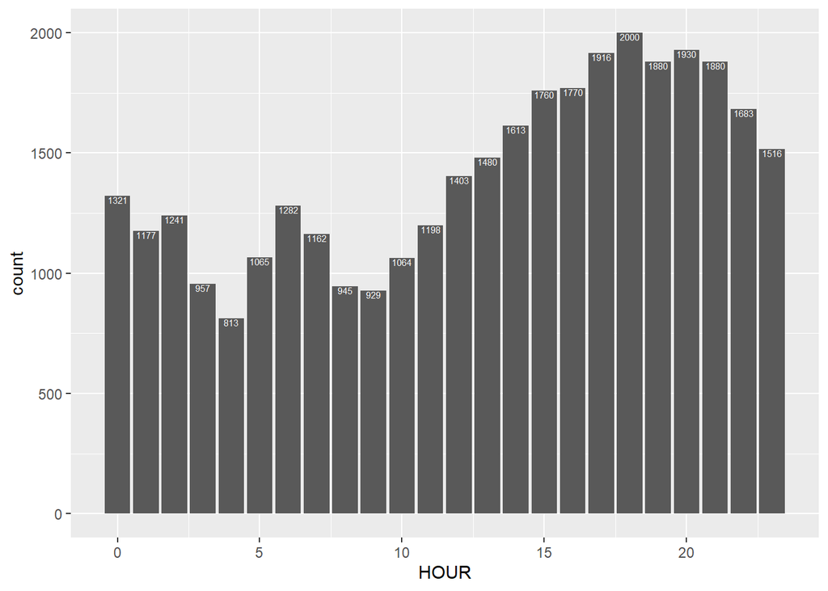

```r
accident %>%
  filter(HOUR != 99) %>%
  ggplot(aes(x = HOUR)) + geom_bar() + geom_text(stat = "count", aes(label = stat(count)),vjust=1, color="white", size=2)
```

The accidents happen from 14 to 23 o’clock in a day. The most accidents happen at 18 o’clock.

3. what is the number of accidents with at least one drunk driver (use variable DRUNK_DR)?

```r
accident %>%
  filter(DRUNK_DR >= 1) %>%
  nrow()
```

```
## [1] 8769
```

The number of accidents with at least one drunk driver is 8769.

4. In the person table, dentify drivers (PER_TYP == 1, see FARS manual) and subset on them.

```r
drivers <- subset(person,PER_TYP == 1)
```

5. Join accident and person table (work out which variable(s) to use)

```r
connection <- accident %>%
  full_join(person, by = c("STATE", "ST_CASE","COUNTY", "DAY", "MONTH", "HOUR", "MINUTE"))
```

6. Tally the number of accidents by day of the week (DAY_WEEK), hour of the day (HOUR) and gender (SEX). Visualize the results.

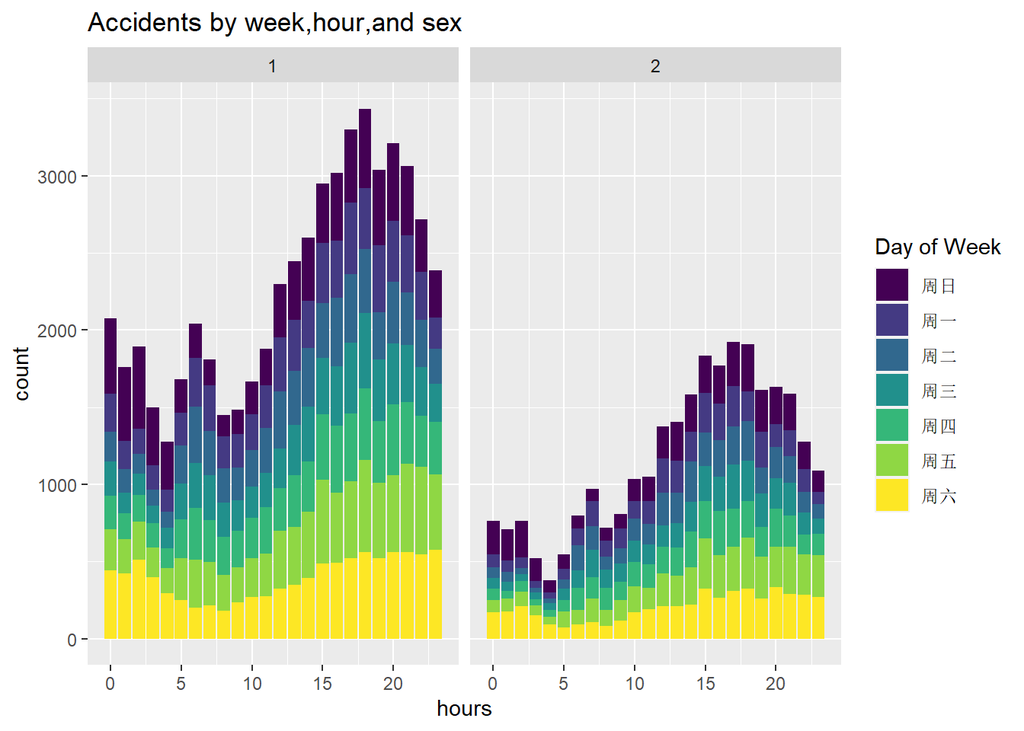

```r
library(lubridate)
connection$SEX <- as.factor(connection$SEX)

connection %>%
  filter(SEX ==1 | SEX ==2) %>%
  filter( HOUR <= 24) %>%
  ggplot(connection, mapping=aes(x=HOUR, fill=wday(DAY_WEEK, label =TRUE) )) +
  geom_bar() + facet_wrap(~SEX) +labs(fill = "Day of Week")  +xlab("hours")+ggtitle("Accidents by week,hour,and sex")
```

7. Now plot a choropleth map of accidents on a county level

Read the description for the STATE and COUNTY columns in the FARS manual. The state & county codes are Geographic Locator Codes (GLCs) from the General Services Administration??s (GSA) publication Use readxl::read_xlsx to read in the GLCs

```r
glcs <- readxl::read_xlsx("GLCs.xlsx")
```

```r
counties <- map_data('county')
counties1 <- counties
acc1 <- accident
glcs$STATE <- glcs$`State Code`
glcs$COUNTY <- glcs$`County Code`
glcs <- glcs%>% select("STATE", "State Name", "COUNTY", "County Name")
accident <- accident %>% select("STATE", "COUNTY", "ST_CASE")

geo1 <- accident %>% join(glcs)
geo1 <- geo1 %>% distinct()
geo1$region <- geo1$`State Name`
geo1$subregion <-geo1$`County Name`
geo1 <- geo1 %>% select(-c("STATE","COUNTY","State Name","County Name"))
geo1$region <- tolower(geo1$region)
geo1$subregion <- tolower(geo1$subregion)
glcs_acc <- geo1 %>% group_by(region, subregion) %>% dplyr::summarise(numAcc =n())
final <- counties1 %>% join(glcs_acc)
```

8. Visualize the number of accidents in each county using a choropleth map. To do this, you need to join the accident data, GLCs, and appropriate map data.

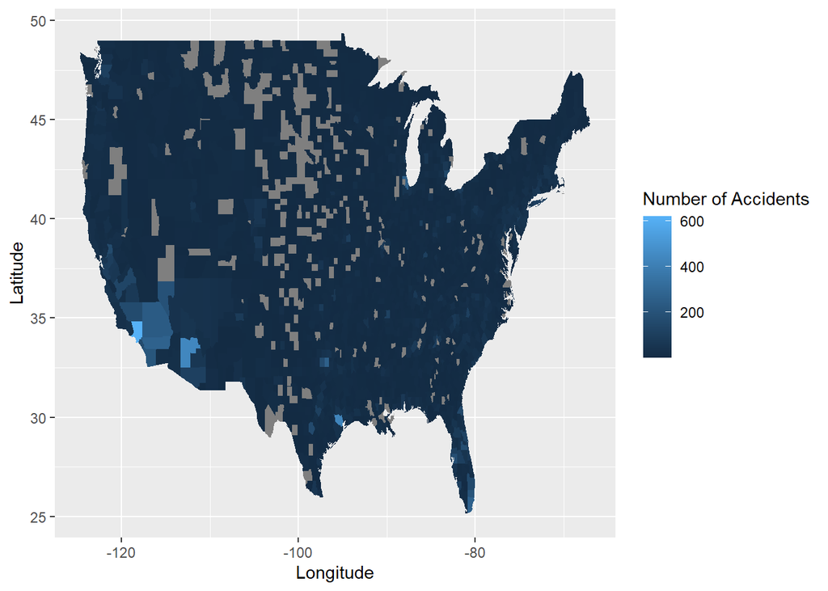

```r
ggplot(final, aes(x=long, y= lat, fill = numAcc)) + geom_polygon(aes(group = group)) +xlab("Longitude") +ylab("Latitude") + labs(fill="Number of Accidents")
```

9. Can you find seasonal trends in accident occurrences in different states? Is summer or winter more dangerous? Why?

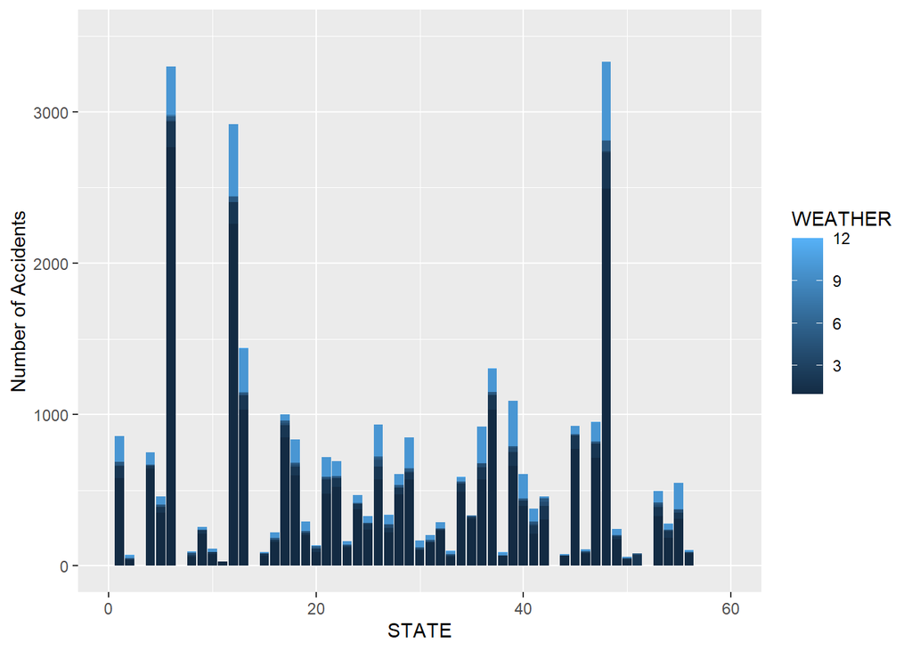

```r
acc1 <- acc1 %>% filter(WEATHER <98)
Weather <- acc1 %>% group_by(STATE, WEATHER) %>% dplyr::summarise(n =n())

ggplot(Weather, aes(x=STATE, y =n, fill = WEATHER)) + geom_bar(stat = "identity") +
  xlim(c(0,60)) +ylim(c(0,3500)) +ylab('Number of Accidents')
```